# Pythonチュートリアル

> python[pάɪθɑn:パイソン]とは汎用プログラミング言語の一種です．  
> pythonではnumpyという数値計算ライブラリをはじめとした様々なライブラリを駆使することで， 複雑な数値シミュレーションも容易に記述することが可能になります．

> ここではpythonの基本的な文法・ツールについて解説します.

## Jupyter notebookについて

> Jupyter notebookとはノートブックとよばれる形式で 作成したプログラムの実行と実行結果を記録しながらデータ分析を進めるツールです. この本文のようなMarkdown形式のセルとpythonのコードを同居させることができるので, 勉強用に技術ノートなり解説なりを作ることが可能です.

> また,C言語の授業で扱ったBCPADのように`Run`を押すだけでプログラムを実行できます. 皆さんが卒業研究でやるようなシミュレーションには不向きですが, プログラミングに慣れるためにはちょうどいいツールです.

> jupyter notebookが嫌になったらその辺の院生に声をかけてください. より良いエディタを紹介します.

## Jupyter notebookの基本的な使い方

> ここでは標準出力`print()`を用いた文字列の表示を例に挙げ,jupyter notebookの基本的な使い方を説明します.

### 1. Jupyter notebookの起動

> ターミナル(コマンドプロンプト)から起動する

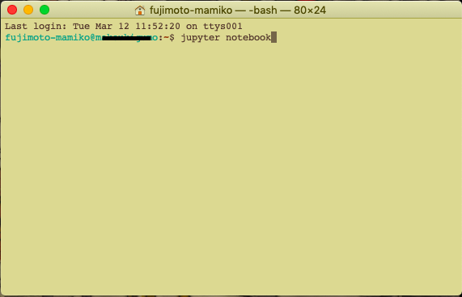

> またはanacondaのメニューから選択する.

[figure not shown]

> ブラウザにこのような画面が立ち上がります. これで起動完了です.

[figure not shown]

### 2. 新しいnotebookファイルの作成

> まずファイルを作りたいディレクトリに移動します. その後`New`をクリックし,pythonを選択します. (ごにょごにょするとpython以外の言語も使えるようになります.)

[figure not shown]

### 3. 準備完了

> Jupyter notebookを起動し,notebookファイルを作ることができました. これで準備完了です.

[figure not shown]

### 4. 実行

> `print()`とは(後にも出てきますが)変数などを表示するための関数です. これを使って知能計測制御研究室のコアタイムを表示しましょう. まずセルのステータスが`code`になっていることを確認し, 下図のように`print("コアタイムは10時30分から18時です")`と入力してください. その後`Run`を押すとセルのプログラムが実行され,実行結果がセルの下に表示されます.

[figure not shown]

> Jupyter notebookの基本的な使い方は以上です. 他の機能については以下の図か,google先生に聞いてください.

[figure not shown]

## データと計算

> プログラムの主な目的はデータを加工して新しいデータを作り出すことです。 研究のプログラムでは主に次の3種類のデータを扱います。
> - 数値  
>   例）日付、時刻、信号、パラメータ
> - 文字列  
>   例）ファイル名、グラフのラベル、シミュレーションの記録
> - 行列  
>   例）線形代数、状態空間、座標データ

> Pythonは数値と文字列を扱うことができ、モジュール（プログラムの部品）を追加することで行列も扱えるようになります。

> 以下ではそれぞれのデータについての紹介とプログラム例を示します。

### 数値

> 数字と記号を使って基本的な数値計算をすることができます。 試しにいくつかの数式を打ち込んで、`print`関数を使って表示してみましょう。

```python
print(123 + 123)
print(123 - 123)
print(123 * 123)

print(1.23 + 1.23)
print(1.23 - 1.23)
print(1.23 * 1.23)

print(123 + 1.23)
print(123 - 1.23)
print(123 * 1.23)
```

```
246
0
15129
2.46
0.0
1.5129
124.23
121.77
151.29
```

> `print`関数は万能な画面出力用の関数で、数値や文字列、行列などの様々なデータを区別せずに表示することができます。

> 明示的には現れませんが、pythonの数値には整数型（`int`）と浮動小数点型（`float`）があります。 `int`同士の計算の答えは`int`、`float`同士の計算は`float`、そして`int`と`float`が混ざった計算は`float`型になります。

> ただしこの規則にはいくつか例外があり、例えば割り算`/`は元の型に関わらず答えは`float`型になります。

```python
print(123/123)
```

```
1.0
```

> `int`型の商が欲しい場合は`//`を使います。

```python
print(123//123)
```

```
1
```

> また `数値 % 数値` とすることで剰余を計算することができ， `数値 ** 数値` とすることで累乗を計算することができます．

```python
print(5%2)
print(5**2)
```

```
1
25
```

> これまでに登場した演算子（計算記号）を表にまとめておきます。

| 記号 | 意味 |
| --- | --- |
| + | 加算 |
| - | 減算 |
| * | 乗算 |
| / | 除算 |
| // | 除算 |
| % | 剰余 |
| ** | 累乗 |

> 計算結果は変数に代入することができます。 変数はコンピュータ上のメモリ（記憶領域）に紐付けられたラベルのことで、代入はラベルと値を対応づける処理です。

> 次のプログラムは計算$12 + 30$の結果を変数`ultimate_answer`に代入します。

```python
ultimate_answer = 12 + 30 # 変数に代入（#以降はコメントと呼ばれ、プログラムとして処理されず無視されます。）
print(ultimate_answer)    # 変数の値を表示（コメントはメモに便利です）
```

```
42
```

> この`=`は等しいことを意味せず、単に変数名と値の対応を示すだけです。 そのため変数に対応づける値を変えたり、変数の値を使って変数自体を更新することができます。

```python
odyssey = 2001
print(odyssey)

odyssey = 2010
print(odyssey)

odyssey = odyssey + 51
print(odyssey)

odyssey = odyssey + 940
print(odyssey)
```

```
2001
2010
2061
3001
```

#### 練習問題

> 次の例題をやってみましょう.
> 1. $4 + 3$を計算し,結果を表示してください.
> 2. $3^2$と$2^3$乗の和を計算し,結果を表示してください.
> 3. 数値$3$を変数`a`に、数値$2$を変数`b`に割り当てて、これらの変数を使って問題2を解いてください。解けたら変数を変えて再計算してみてください。

```python
# 1

# 2

# 3
```

### 文字列

> 文字列はダブルクォート（`"`）またはシングルクォート（`'`）で囲うことでデータとして扱えます。

```python
print("hello, world!")
```

```
hello, world!
```

> 数値と同様に、変数への代入ができます。 文字列に対しては演算子`+`が定義されていて、2つの文字列を結合できます。

```python
s1 = "たけやぶやけた"
s2 = 'あいうえお'
print(s1)
print(s2)
print(s1 + s2)
```

```
たけやぶやけた
あいうえお
たけやぶやけたあいうえお
```

> 文字列の中に数値（例えばそれ以前に処理した計算結果）を埋め込むには、接頭記号`f`とブレース（`{}`）を使います。 クォートに`f`を付けた上でブレースで変数を挟む、すなわち`f"{変数名}"`とすることで埋め込めます。 これは次の例を見るほうがわかりやすいでしょう。

```python
odyssey1 = 2001
odyssey2 = 2010
odyssey3 = odyssey2 + 51
odyssey4 = odyssey3 + 940

title1 = f"An odyssey in {odyssey1}"
title2 = f"An odyssey in {odyssey2}"
title3 = f"An odyssey in {odyssey3}"
title4 = f"An odyssey in {odyssey4}"

print(title1)
print(title2)
print(title3)
print(title4)
```

```
An odyssey in 2001
An odyssey in 2010
An odyssey in 2061
An odyssey in 3001
```

#### 練習問題

> 1. 変数`core_hour`と`core_minute`に知能計測制御研究室のコアタイムの時間、分を数値として代入し、`コアタイムはHH:MM`の形式で表示してください。

```python
# 1
```

### 行列

> Pythonには標準で行列を扱う機能がありません（もちろん自力で実装はできるが、非常に困難）。 行列計算は多くの人が使う機能であるため、有志が作成した**numpy**という行列をはじめとした数値計算のための外部ライブラリ（pythonに付属していないが、追加で導入できる機能群）があります。

> numpyを使ったプログラム例を示します。 このプログラムは$2 \times 2$行列$A, B$の内積$C$を計算します。 記号を大文字にしたのは趣味です。

```python
import numpy

A = numpy.array([[1, 2], [3, 4]])
B = numpy.array([[5, 6],
                 [7, 8]])
print(A)
print(B)

C = A @ B
print(C)
```

```
[[1 2]
 [3 4]]
[[5 6]
 [7 8]]
[[19 22]
 [43 50]]
```

> 1行目でnumpyを読み込み、以降のプログラムで使えるようにします。 3, 4行目で行列A, Bを定義します。 numpyの行列なので、`array`の前に`numpy`を`.`で付けています。 9行目で内積を計算します。 `@`は内積の演算子（計算記号）です。

> 行列同士の演算は内積以外にも、
> - 要素和
> - 要素差
> - 要素積
> - 要素商

> などが定義されています。

```python
import numpy as np

A = np.array([[1, 2], [3, 4]])
B = np.array([[5, 6], [7, 8]])

print("Aの転置:")
print(A.T)

print("要素和:")
print(A + B)

print("要素差:")
print(A - B)

print("要素積:")
print(A * B)

print("要素商:")
print(A / B)
```

```
Aの転置:
[[1 3]
 [2 4]]
要素和:
[[ 6  8]
 [10 12]]
要素差:
[[-4 -4]
 [-4 -4]]
要素積:
[[ 5 12]
 [21 32]]
要素商:
[[0.2        0.33333333]
 [0.42857143 0.5       ]]
```

> このプログラムでは別の方法でnumpyをインポートしています。 `import`でnumpyを読み込むのは同様ですが、変数`np`にnumpyを割り当てています。 こうするとnumpyの代わりに`np`を接頭語として使うことができ、指の関節を節約できます。

```python
import numpy as np
import numpy.linalg as nl

A = np.array([[1, 2], [3, 4]])
print(A)

print("1, 1要素")
print(A[0, 0])

print("2, 1要素")
print(A[1, 0])
```

```
[[1 2]
 [3 4]]
1, 1要素
1
2, 1要素
3
```

> また,逆行列,行列式の計算は以下のように行います. 逆行列、行列式はnumpyだけでは計算できないので、さらに`numpy.linalg`をインポートしています。

```python
import numpy as np
import numpy.linalg as nl

A = np.array([[1, 2], [3, 4]])

print("逆行列:")
print(nl.inv(A))

print("行列式:")
print(nl.det(A))
```

```
逆行列:
[[-2.   1. ]
 [ 1.5 -0.5]]
行列式:
-2.0000000000000004
```

#### 練習問題

```python
# 1

# 2
```

### その他のデータ型

> 上で挙げた数値、文字列、行列以外にもデータ型はあります。 しかし研究のプログラムでは扱わない、または明示的に扱う必要がないデータので、列挙して紹介するに留めます。
> - 真偽型  
>   `True`と`False`の2値。ブール代数（論理代数）が使える。後述する条件分岐にて説明するのでここでは省略
> - リスト型  
>   可変長の配列。基本的で重要な型だが`np.ndarray`と用途が被っているので省略
> - 辞書型  
>   キーと値のペアで構成される型。numpyが計算の結果として返してくることがあるが、そのときに勉強したらよいので省略

## 関数

> 関数は一般的にあるデータを受け取り，何らかの規則で変換した結果を返すものです。 Pythonで関数を作る方法は`def`を使う方法と`lambda`を使う方法がありますが、ここでは`lambda`を使った無名関数を作る方法を説明します. 無名関数は以下で定義できます.

> `lambda 引数:戻り値(処理の内容)`

> 例えば,次のセルでは受け取った値$x$の平方$\sqrt{x}$を返す関数`sqrt`を定義して、$\sqrt{2}$を計算しています。

```python
# 目的: xの平方根を計算する
# 型: float -> float
sqrt = lambda x:x**0.5

print(sqrt(2))
```

```
1.4142135623730951
```

> 関数を定義することの利点は可読性を維持しつつ処理を繰り返すことができる点です。 処理を関数宣言の1箇所にまとめてほかの箇所で使いまわすことで、修正が必要になったとき変更すべき箇所が減ることも利点です。 これらの利点はプログラムの保守性を高めます。

> 関数を使いまわす例を見てみましょう。 次の`mid_point`はベクトル（`np.ndarray`型）で与えられた2点の中点を求める関数です。

```python
# 目的: 与えられたベクトルp1, p2の中点を計算する
# 型: (np.ndarray, np.ndarray) -> np.ndarray
mid_point = lambda p1, p2: (p1 + p2) / 2
```

> 2点間を1:3で内分する処理は次のように`mid_point`関数を再利用して構築できます。

```python
# 目的: 与えられた2点間を1:3に内分する点を計算する
# 型: (np.ndarray, np.ndarray) -> np.ndarray
divide_1_3 = lambda p1, p2: mid_point(p1, mid_point(p1, p2))
```

```python
point_left = np.array([0, 0])
point_right = np.array([4, 8])

point_m = mid_point(point_left, point_right)
point_q = divide_1_3(point_left, point_right)

print(point_m)
print(point_q)
```

```
[2. 4.]
[1. 2.]
```

> プログラムを書くときのコツとして、**関数の入力と出力が何であるか**を意識して書く方法があります。 関数を書くときは上の例のように、何を受け取り何を求めるかを示す**目的**と、受け取るデータと返すデータの**型**をコメント文で明記すべきです。

> コメントを書くのは多少めんどうですが、習熟速度が段違いに変わるので**必ず**書くようにしましょう。

#### 練習問題

> 1. 受け取った数に対して,逆数をかけた数を出力する関数を書いてください
> 2. 三角形の3辺$a, b, c$を受け取り角$\angle C$の余弦$\cos(\angle C)$を求める関数`cos_c`を書いてください
> 3. `cos_c`を再利用して、3辺から三角形の面積を求める関数`tri_area`を書いてください
> 4. `tri_area`を再利用して、3辺から三角形の内接円の半径を求める関数`rad_insc_circle`を書いてください

```python
# 1

# 2

# 3

# 4
```

## 条件分岐

> ある条件を満たすときだけ処理を実行する、または満たさないとき処理を実行するためにpythonではif文やif式を使うことができます。

> 条件とは真偽型の値を返す式や関数、あるいは真偽値そのものを指します。 例えば「値`x`が偶数である」という条件は剰余を求める演算子`%`と両辺が等しいかを判定する演算子`==`を使って次のように書くことができます。

```python
x = 42
condition = x % 2 == 0

print(condition)
```

```
True
```

> 値`42`は偶数なので、`condition`の値は`True`になっています。 奇数の場合も示します。

```python
x = 43

print(x % 2 == 0)
```

```
False
```

> こちらでは変数に代入しないで条件式の値を直接プリントしました。 この場合は`x`が偶数でないので、`False`が出力されました。

> 条件判定に使う`==`などの演算子はまとめて条件演算子と呼ばれます。 よく使うほかの条件演算子を次に示します。

| 記号 | 意味 |
| --- | --- |
| == | 等号 $=$ |
| != | 等号 $\neq$ |
| < | 不等号 $<$ |
| > | 不等号 $>$ |
| <= | 不等号 $\leq$ |
| >= | 不等号 $\geq$ |

> これらの演算子を使って処理を切り替える方法を見ていきます。

### if文

> if文は次の形式で書きます。

> ```
> if 条件式1:
>    条件1を満たすときの処理
> elif 条件式2:
>    条件2を満たすときの処理
> else:
>    条件1, 2のどちらも満たさないときの処理
> ```

> それぞれの処理は字下げ幅（先頭の空白の幅）を揃えることで複数列挙できます。 `elif`, `else`は必要なければ省略できます。 if文は複数行を使って書かなければならないため、原則1行で書かなければならない無名関数の中で使うことはできません。

> 次のコードは`year`がうるう年かどうかに応じて出力する文字を切り替えます。 if文が二重になっているため少し読みづらいですが、`year`の値を色々変えながら処理の流れを探ってみてください。

```python
year = 2019

if year % 400 == 0: # 西暦年が400で割り切れる年は必ずうるう年
    print(f"{year}年はうるう年")
elif year % 4 == 0: # 西暦年が4で割り切れる年は（原則として）うるう年
    if year % 100 == 0: # 西暦年が100で割り切れる年は（原則として）平年
        print(f"{year}年は平年")
    else:
        print(f"{year}年はうるう年")
else:
    print(f"{year}年は平年")
```

```
2019年は平年
```

#### 練習問題

> 1. 24時間表記の時刻`h`と`m`を受け取り、弊研究室のコアタイムに含まれるかを判定しましょう

```python
# 1
```

### if式

> if式は次の形式で書きます。

> ```
> 値1 if 条件式 else 値2
> ```

> 条件式を満たすときは値1、満たさないときは値2が使われます。 if文と違って`elif`はありませんし、`else`を省略することができません。 これは必ずなんらかの値を返すための制約です。 その代わりif式はその他の計算式に埋め込むことができ、すなわち無名関数の中で使うことができます。

> if式を使うとクロネッカーのデルタ、

> \begin{equation} \delta_{i, j} = \begin{cases} 1 & i = j \\ 0 & \text{otherwise} \end{cases} \end{equation}

> は次の無名関数として実装できます。

```python
# 目的: クロネッカーのデルタ（iとjが等しいとき1、それ以外は0を返す）を実装する
# 型: (int, int) -> int
kronecker_delta = lambda i, j: 1 if i == j else 0

print(kronecker_delta(1, 2))
print(kronecker_delta(1, 1))
```

```
0
1
```

#### 練習問題

> 1. 2つの浮動小数`a`, `b`を受け取り大きいほうを返す`max2`関数を作りましょう
> 2. 3つの浮動小数`a`, `b`, `c`を受け取り最も大きいものを返す`max3`関数を作りましょう（ヒント: `max2`を再利用します）

```python
# 1

# 2
```

## 繰り返し（ループ）

> 処理を繰り返す方法にはfor文とwhile文の2つが用意されています。 C言語にあるdo-while文やgoto文はpythonにはありません。

### for文

> Pythonのfor文はC言語のfor文とは異なる動作をします。 Pythonのforはイテレータ（`np.ndarray`型やここでは説明していないリスト型など）の各要素に対して処理を行うときに使われます。

> 整数`0`から`9`までを順番に画面表示するコードを示します。

```python
import numpy as np

for i in np.arange(10):
    print(i)
```

```
0
1
2
3
4
5
6
7
8
9
```

> ここで`np.arange(10)`は`np.ndarray([0, 1, ..., 9])`を返す関数です。 つまりこの処理は`np.ndarray`の要素である`0`, `1`, ..., `9`を順番に変数`i`に束縛し、それぞれの`i`に関して`print`関数を呼び出しています。 このイテレータは連番である必要はなく、例えば次のようなベクトル`v`にもfor文を適用できます。

```python
import numpy as np

v = np.array([3.14, 42.0, 1701.0])

for f in v:
    print(f * 10.0)
```

```
31.400000000000002
420.0
17010.0
```

> for文は二重、三重にできます。

```python
for i in np.arange(3):
    for j in np.arange(3):
        print(i + j)
```

```
0
1
2
1
2
3
2
3
4
```

> ここで気をつけてほしいのが、`v`は**行列**ではなく**ベクトル**である点です。 違いをはっきりさせるために、意味的には等価ですが次元が異なる行列`M`とベクトル`m`を示します。

```python
M = np.array([[1, 2, 3]])
m = np.array([1, 2, 3])

print("行列M")
print(M)
print("ベクトルm")
print(m)
```

```
行列M
[[1 2 3]]
ベクトルm
[1 2 3]
```

> `M`は2次元の配列として定義された行列ですが、`m`は1次元の配列として定義されたベクトルです。 このことはそれぞれに`np.ndim`関数を適用した結果からも確認できます。

```python
print("行列Mの次数")
print(np.ndim(M))
print("ベクトルmの次数")
print(np.ndim(m))
```

```
行列Mの次数
2
ベクトルmの次数
1
```

> 行列とベクトルにfor文を適用すると異なる結果になります。

```python
print("行列Mの場合")
for i in M:
    print(i)
print("ベクトルmの場合")
for i in m:
    print(i)
```

```
行列Mの場合
[1 2 3]
ベクトルmの場合
1
2
3
```

> 行列`M`にfor文を適用すると、1行目`[1 2 3]`が丸ごと取り出されます。 `M`に対する動作を`m`と同じようにするには、`np.reshape`関数で`M`を1次元にしてから使いましょう。

```python
# (1, 3)行列を(3,)ベクトルに変換する。
# 数字数えるのがめんどうなら、
# (-1,)と書くと自動でやってくれる。
reshaped_M = np.reshape(M, (3,))

for i in reshaped_M:
    print(i)
```

```
1
2
3
```

#### 練習問題

> 1. 1から100までの数字を合計して表示しましょう
> 2. for文を二重に使って、各インデックスの組に対して`kronecker_delta(i, j)`を計算して表示してみましょう

```python
# 1

# 2
```

### while文

> while文の働きはC言語のものとよく似ています。 括弧がない点、コロンを使う点を除くと文法も同じなので、ここでは使用例だけ示します。 for文の練習問題1はwhile文を使うと次のように書けます。

```python
total = 0
i = 1
while i <= 100:
    total = total + i
    i = i + 1

print(total)
```

```
5050
```

> ただしfor文を使うほうがスッキリするので普通はやりません。

> while文を使うのは終了条件を満たすまで処理を繰り返したいときです。 次の例は[ニュートン法](https://ja.wikipedia.org/wiki/%E3%83%8B%E3%83%A5%E3%83%BC%E3%83%88%E3%83%B3%E6%B3%95)というアルゴリズムを使って方程式$x^2 - 42 = 0$の解、すなわち$\sqrt{42}$を計算しています。 解の更新量`update`がしきい値$1 \times 10^{-10}$を下回るまで更新を繰り返します。

```python
import numpy as np

f = lambda x: x**2 - 42
df = lambda x: 2*x

x = 3.14
update = f(x)/df(x)

while abs(update) > 1E-10:
    x = x - update
    update = f(x)/df(x)

print(x)
```

```
6.480740698407886
```

#### 練習問題

> 1. 300,000を超える最小のフィボナッチ数を計算しましょう

```python
# 1
```

## 研究で使うライブラリ、テクニック

> 以上がpythonの基礎でした。 説明していないものもたくさんありますが、それは必要となったときに各自で調べるようにしてください。

> ここからは研究で使うライブラリやテクニックを紹介します。 特にグラフを作るmatplotlibは必須ですので使い方を覚えましょう。

### もっとnumpy

> numpyで個人的によく使う関数を紹介します。 数が多いので説明はコメントにて簡単に述べるに留めます。

```python
import numpy as np

print(np.linspace(0, 1, 3)) # 範囲を線形に分割したベクトル
print(np.zeros(4)) # 指定サイズのゼロベクトル
print(np.zeros((2, 3))) # 指定サイズのゼロ行列
print(np.ones((2, 3))) # すべてが1のベクトルまたは行列
print(np.eye(3)) # 単位行列
print(np.array([[1, 2], [3, 4]])[1,:]) # 行列の特定行を抜き出す
print(np.array([[1, 2], [3, 4]])[:,1]) # 行列の特定列を抜き出す
```

```
[0.  0.5 1. ]
[0. 0. 0. 0.]
[[0. 0. 0.]
 [0. 0. 0.]]
[[1. 1. 1.]
 [1. 1. 1.]]
[[1. 0. 0.]
 [0. 1. 0.]
 [0. 0. 1.]]
[3 4]
[2 4]
```

### グラフ作成モジュール(matplotlib)

> matplotlibはグラフを表示するためのライブラリです。 実用上はmatplotlibのサブモジュールであるmatplotlib.pyplotを使うことになります。

> `plot`関数でグラフを描画し、`show`関数で画面に表示します。 `show`するまでは`plot`したものは確認できないので、`show`を呼ぶことを忘れないようにしましょう。

```python
import numpy as np
import matplotlib.pyplot as plt

# 0~2piの範囲のsin(x)を計算する
sine = 12*np.sin(np.linspace(0, 2*np.pi, 201))
cose = 9*np.cos(np.linspace(0, 2*np.pi, 201))

# `sine`を線グラフにする
plt.plot(sine)
plt.plot(cose)

# グラフを表示する
plt.show()
```

[output not shown]

> `plot`の引数に`label=`を与えることで、線に名前をつけれます。 `show`の前に`legend`を忘れないようにしましょう。

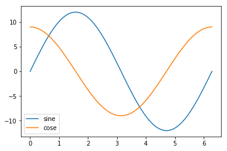

```python
import numpy as np
import matplotlib.pyplot as plt

# 横軸
time = np.linspace(0, 2*np.pi, 201)

# 0~2piの範囲のsin(x)を計算する
sine = 12*np.sin(time)
cose = 9*np.cos(time)

# `sine`を線グラフにする
plt.plot(time, sine, label="sine") # ラベルつき
plt.plot(time, cose, label="cose") # ラベルつき

plt.legend() # ラベルをグラフ内に表示

# グラフを表示する
plt.show()
```

> 軸ラベルは`xlabel`, `ylabel`でつけれます。

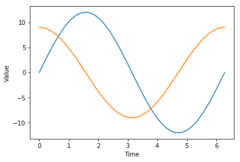

```python
import numpy as np
import matplotlib.pyplot as plt

# 横軸
time = np.linspace(0, 2*np.pi, 201)

# 0~2piの範囲のsin(x)を計算する
sine = 12*np.sin(time)
cose = 9*np.cos(time)

# `sine`を線グラフにする
plt.plot(time, sine)
plt.plot(time, cose)

plt.xlabel("Time")
plt.ylabel("Value")

# グラフを表示する
plt.show()
```